# DADA2 - MLSH ITS2 Plate 3 & 4

# Execute cutadapt from bash script through ssh

The system command was not working properly, so used R to generate adapter and RC sequences and ran bash_cutadapt.sh script.

```r
# cutadapt <- "/home/bryan.emmett/.local/bin/cutadapt"
# system2(command = cutadapt, args = "--version")
```

### Create directory for trimmed sequences

```r
path.cut <- file.path(path, "cutadapt")
if(!dir.exists(path.cut)) dir.create(path.cut)
fnFs.cut <- file.path(path.cut, basename(fnFs))
fnRs.cut <- file.path(path.cut, basename(fnRs))
```

### Define primers

```r
FWD.RC <- dada2:::rc(FWD)
REV.RC <- dada2:::rc(REV)
FWD
```

```
[1] "AACTTTYRRCAAYGGATCWCT"
```

```r
REV
```

```
[1] "AGCCTCCGCTTATTGATATGCTTAART"
```

```r
FWD.RC
```

```
[1] "AGWGATCCRTTGYYRAAAGTT"
```

```r
REV.RC
```

```
[1] "AYTTAAGCATATCAATAAGCGGAGGCT"
```

```r
R1.flags <- paste("-g", FWD, "-a", REV.RC)
R2.flags <- paste("-G", REV, "-A", FWD.RC)
R1.flags
```

```
[1] "-g AACTTTYRRCAAYGGATCWCT -a AYTTAAGCATATCAATAAGCGGAGGCT"
```

```r
R2.flags
```

```
[1] "-G AGCCTCCGCTTATTGATATGCTTAART -A AGWGATCCRTTGYYRAAAGTT"
```

```r
fnRs.cut[1]
```

[output not shown]

## Check cut adapt

```r
rbind(FWD.ForwardReads = sapply(FWD.orients, primerHits, fn = fnFs.cut[[1]]), FWD.ReverseReads = sapply(FWD.orients,
    primerHits, fn = fnRs.cut[[1]]), REV.ForwardReads = sapply(REV.orients, primerHits,
    fn = fnFs.cut[[1]]), REV.ReverseReads = sapply(REV.orients, primerHits, fn = fnRs.cut[[1]]))
```

```
                 Forward Complement Reverse
FWD.ForwardReads       0          0       0
FWD.ReverseReads       0          0       0
REV.ForwardReads       0          0       0
REV.ReverseReads       0          0       0
                 RevComp
FWD.ForwardReads       0
FWD.ReverseReads       0
REV.ForwardReads       0
REV.ReverseReads       0
```

Check for the sequencing adapters to see if there are similar counts

```r
rbind(
  FSEQ.ForwardReads = sapply(FSEQ.orients, primerHits, fn = fnFs.cut[[1]]),
  FSEQ.ReverseReads = sapply(FSEQ.orients,
    primerHits, fn = fnRs.cut[[1]]),
  RSEQ.ForwardReads = sapply(RSEQ.orients, primerHits,
    fn = fnFs.cut[[1]]),
  RSEQ.ReverseReads = sapply(RSEQ.orients, primerHits, fn = fnRs.cut[[1]]))
```

```
                  Forward Complement Reverse
FSEQ.ForwardReads       0          0       0
FSEQ.ReverseReads       0          0       0
RSEQ.ForwardReads       0          0       0
RSEQ.ReverseReads       0          0       0
                  RevComp
FSEQ.ForwardReads       0
FSEQ.ReverseReads       0
RSEQ.ForwardReads       0
RSEQ.ReverseReads       0
```

changing path to cut files to target new cutadapt2 folder

```r
path.cut2 <- file.path(path, "cutadapt2")
#if(!dir.exists(path.cut)) dir.create(path.cut)
fnFs.cut <- file.path(path.cut2, basename(fnFs))
fnRs.cut <- file.path(path.cut2, basename(fnRs))
```

```r
fnFs.cut[1]
```

```
[1] "/project/mmicrobe/MLSH/ITS2/raw/Plate1-2/lane1/cutadapt2/MLSH_ITS2_1_S1_L001_R1_001.fastq.gz"
```

```r
rbind(
  FSEQ.ForwardReads = sapply(FSEQ.orients, primerHits, fn = fnFs.cut[[1]]),
  FSEQ.ReverseReads = sapply(FSEQ.orients,
    primerHits, fn = fnRs.cut[[1]]),
  RSEQ.ForwardReads = sapply(RSEQ.orients, primerHits,
    fn = fnFs.cut[[1]]),
  RSEQ.ReverseReads = sapply(RSEQ.orients, primerHits, fn = fnRs.cut[[1]]))
```

```
                  Forward Complement Reverse
FSEQ.ForwardReads       0          0       0
FSEQ.ReverseReads       0          0       0
RSEQ.ForwardReads       0          0       0
RSEQ.ReverseReads       0          0       0
                  RevComp
FSEQ.ForwardReads       0
FSEQ.ReverseReads       0
RSEQ.ForwardReads       0
RSEQ.ReverseReads       0
```

```r
# Forward and reverse fastq filenames have the format:
cutFs <- sort(list.files(path.cut2, pattern = "_R1_001.fastq.gz", full.names = TRUE))
cutRs <- sort(list.files(path.cut2, pattern = "_R2_001.fastq.gz", full.names = TRUE))

# Extract sample names, assuming filenames have format:
get.sample.name <- function(fname) strsplit(basename(fname), "_S")[[1]][1]
sample.names <- unname(sapply(cutFs, get.sample.name))
head(sample.names)
```

```
[1] "MLSH_ITS2_1"   "MLSH_ITS2_100"
[3] "MLSH_ITS2_101" "MLSH_ITS2_102"
[5] "MLSH_ITS2_103" "MLSH_ITS2_104"
```

```r
sample.names
```

```
  [1] "MLSH_ITS2_1"
  [2] "MLSH_ITS2_100"
  [3] "MLSH_ITS2_101"
  [4] "MLSH_ITS2_102"
  [5] "MLSH_ITS2_103"
  [6] "MLSH_ITS2_104"
  [7] "MLSH_ITS2_105"
  [8] "MLSH_ITS2_106"
  [9] "MLSH_ITS2_107"
 [10] "MLSH_ITS2_109"
 [11] "MLSH_ITS2_110"
 [12] "MLSH_ITS2_111"
 [13] "MLSH_ITS2_112"
 [14] "MLSH_ITS2_113"
 [15] "MLSH_ITS2_114"
```

[output cut: 169 more lines]

# Plot quality profiles and forward and reverse reads

## Forward reads

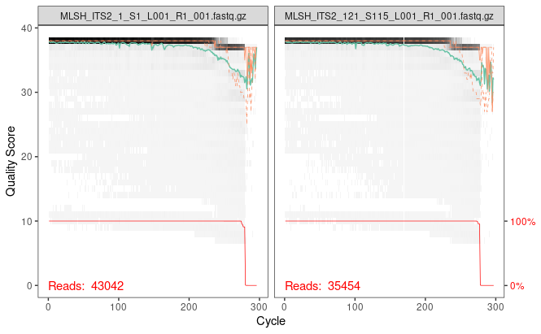

```r
plotQualityProfile(fnFs.cut[c(1,22)])
```

Some files had zero lengths. Re-running the cutadapt script with sequencing adapters and ‘-m 50’ removed these sequences and short sequences. Looks like files may be ready to go.

## Reverse reads

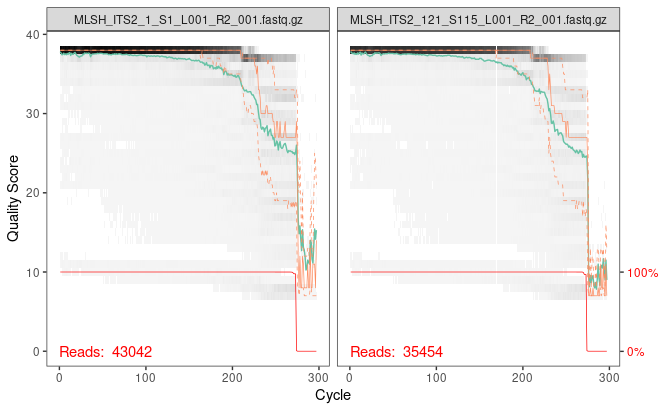

```r
plotQualityProfile(fnRs.cut[c(1,22)])
```

## Last check

```r
readLines(fnFs.cut[1], n = 4)
```

```
[1] "@M01479:483:000000000-L7J6D:1:1102:8598:1865 1:N:0:CCGTAGTTTAGG+CCTAAACTACGG"
[2] "TGGTTCTGGCATCGATGAAGAACGCAGCGAAATGCGATACGTAATGTGAATTGCAGATTT…"
[3] "+"
[4] "GGGGGGGGGGGGGGGGGGGGGGGGGGGGGGGGGGGGGGGGGGGGGGGGGGGGGGGGGGGG…>E>=CE8CE7CC**:***1*07:>+**8*:*09*0./.)****.*)0(..*.)67).:))((-(((*)-,((.(-(."
```

```r
readLines(fnRs.cut[1], n = 4)
```

```
[1] "@M01479:483:000000000-L7J6D:1:1102:8598:1865 2:N:0:CCGTAGTTTAGG+CCTAAACTACGG"
[2] "TCAGCTTTTATTCCTACCTGATCCGATTTCAACCTTGATATGTTGGGTGTTTCACGGCAA…"
[3] "+"
[4] "C@,,6,,,;,<C6<C,6@C@,CC@,,,,:<,,<;CC,,<,C,C,,,+,,8BC,,<,,+++,,,:6:+88,8,:=<65:,,,9,,:,,:,:AE,:A,5,9:4+,4+8,,9++6+++644++6++6,,,385+****35@,,,,2,,26*4***,4222,,6*1***/3<+*++553++5++4<*++4++2++0**+*2***/*0*22**.0))))/)10*10*/))))/)-).--).6))))((.,)))66).4.).6)))).).)))).6-)-"
```

```r
#path
#fastqFs[1]
```

# Filter and trim

```r
filtFs <- file.path(path.cut2, "filtered", basename(cutFs))
filtRs <- file.path(path.cut2, "filtered", basename(cutRs))
```

```r
out <- filterAndTrim(cutFs, filtFs, cutRs, filtRs, maxN = 0, maxEE = c(2, 2), truncQ = 8,
    minLen = 50, rm.phix = TRUE, compress = TRUE, multithread = ncores)  # on windows, set multithread = FALSE
```

```r
head(out)
```

```
                                       reads.in
MLSH_ITS2_1_S1_L001_R1_001.fastq.gz       43042
MLSH_ITS2_100_S94_L001_R1_001.fastq.gz    58098
MLSH_ITS2_101_S95_L001_R1_001.fastq.gz    58427
MLSH_ITS2_102_S96_L001_R1_001.fastq.gz    43241
MLSH_ITS2_103_S97_L001_R1_001.fastq.gz    35803
MLSH_ITS2_104_S98_L001_R1_001.fastq.gz    41583
                                       reads.out
MLSH_ITS2_1_S1_L001_R1_001.fastq.gz        41362
MLSH_ITS2_100_S94_L001_R1_001.fastq.gz     56104
MLSH_ITS2_101_S95_L001_R1_001.fastq.gz     56140
MLSH_ITS2_102_S96_L001_R1_001.fastq.gz     41409
MLSH_ITS2_103_S97_L001_R1_001.fastq.gz     34302
MLSH_ITS2_104_S98_L001_R1_001.fastq.gz     39734
```

```r
OutFolder = "/project/mmicrobe/MLSH/ITS2/Plate1-2"
saveRDS(out, file.path(OutFolder,'FilterTrim.rds'))
```

# Learn errors

```r
set.seed(100)
# Learn forward error rates
errF <- learnErrors(filtFs, multithread = ncores)
```

```
100306270 total bases in 364225 reads from 9 samples will be used for learning the error rates.
```

```r
# Learn reverse error rates
errR <- learnErrors(filtRs, multithread=ncores)
```

```
107765434 total bases in 441082 reads from 11 samples will be used for learning the error rates.
```

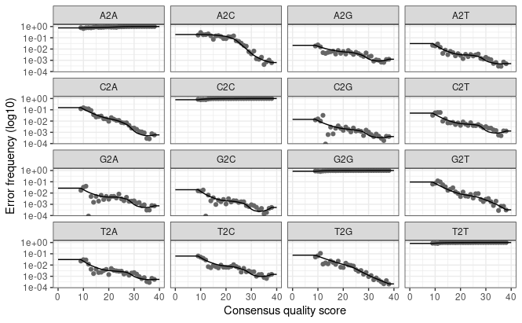

```r
plotErrors(errF)
```

```r
errF_File = file.path(OutFolder,"errF.rds")
saveRDS(errF, errF_File)

errR_File = file.path(OutFolder,"errR.rds")
saveRDS(errR, errR_File)
```

# Sequence Inference

```r
dadaFs <- dada(filtFs, err = errF, multithread = TRUE)
```

```
Sample 1 - 41362 reads in 13504 unique sequences.
Sample 2 - 56104 reads in 14464 unique sequences.
Sample 3 - 56140 reads in 13365 unique sequences.
Sample 4 - 41409 reads in 10394 unique sequences.
Sample 5 - 34302 reads in 9187 unique sequences.
Sample 6 - 39734 reads in 11210 unique sequences.
Sample 7 - 32597 reads in 10283 unique sequences.
Sample 8 - 28073 reads in 9335 unique sequences.
Sample 9 - 34504 reads in 10764 unique sequences.
Sample 10 - 41933 reads in 11983 unique sequences.
Sample 11 - 34924 reads in 10729 unique sequences.
Sample 12 - 30239 reads in 9379 unique sequences.
Sample 13 - 34458 reads in 10361 unique sequences.
Sample 14 - 20624 reads in 7659 unique sequences.
Sample 15 - 35151 reads in 12119 unique sequences.
Sample 16 - 31261 reads in 10993 unique sequences.
Sample 17 - 36182 reads in 11147 unique sequences.
Sample 18 - 33954 reads in 7461 unique sequences.
Sample 19 - 23691 reads in 6564 unique sequences.
Sample 20 - 22891 reads in 6775 unique sequences.
Sample 21 - 29813 reads in 7319 unique sequences.
Sample 22 - 34168 reads in 10352 unique sequences.
Sample 23 - 39677 reads in 12822 unique sequences.
Sample 24 - 29910 reads in 9194 unique sequences.
Sample 25 - 17174 reads in 6631 unique sequences.
Sample 26 - 19728 reads in 6950 unique sequences.
Sample 27 - 36223 reads in 11240 unique sequences.
Sample 28 - 36488 reads in 11586 unique sequences.
Sample 29 - 30771 reads in 10182 unique sequences.
Sample 30 - 29348 reads in 9650 unique sequences.
Sample 31 - 32296 reads in 10467 unique sequences.
Sample 32 - 29111 reads in 10508 unique sequences.
Sample 33 - 46382 reads in 10990 unique sequences.
Sample 34 - 31241 reads in 9978 unique sequences.
Sample 35 - 46833 reads in 14395 unique sequences.
Sample 36 - 24752 reads in 8869 unique sequences.
Sample 37 - 25579 reads in 8863 unique sequences.
Sample 38 - 27046 reads in 8112 unique sequences.
Sample 39 - 42381 reads in 10130 unique sequences.
Sample 40 - 35661 reads in 10338 unique sequences.
```

[output cut: 129 more lines]

```
Sample 170 - 40347 reads in 16016 unique sequences.
Sample 171 - 42742 reads in 14515 unique sequences.
Sample 172 - 39671 reads in 13736 unique sequences.
Sample 173 - 32718 reads in 9443 unique sequences.
Sample 174 - 51937 reads in 14898 unique sequences.
Sample 175 - 62891 reads in 17164 unique sequences.
Sample 176 - 47134 reads in 15553 unique sequences.
Sample 177 - 59270 reads in 20058 unique sequences.
Sample 178 - 39286 reads in 11377 unique sequences.
Sample 179 - 234 reads in 42 unique sequences.
Sample 180 - 1 reads in 1 unique sequences.
Sample 181 - 2 reads in 2 unique sequences.
Sample 182 - 2 reads in 2 unique sequences.
Sample 183 - 33576 reads in 10770 unique sequences.
Sample 184 - 40189 reads in 10804 unique sequences.
```

```r
dadaRs <- dada(filtRs, err = errR, multithread = TRUE)
```

```
Sample 1 - 41362 reads in 18286 unique sequences.
Sample 2 - 56104 reads in 22236 unique sequences.
Sample 3 - 56140 reads in 25815 unique sequences.
Sample 4 - 41409 reads in 15109 unique sequences.
Sample 5 - 34302 reads in 16089 unique sequences.
Sample 6 - 39734 reads in 16411 unique sequences.
Sample 7 - 32597 reads in 13536 unique sequences.
Sample 8 - 28073 reads in 13155 unique sequences.
Sample 9 - 34504 reads in 14894 unique sequences.
Sample 10 - 41933 reads in 17059 unique sequences.
Sample 11 - 34924 reads in 15632 unique sequences.
Sample 12 - 30239 reads in 13918 unique sequences.
Sample 13 - 34458 reads in 15477 unique sequences.
Sample 14 - 20624 reads in 12461 unique sequences.
Sample 15 - 35151 reads in 15759 unique sequences.
Sample 16 - 31261 reads in 15688 unique sequences.
Sample 17 - 36182 reads in 13918 unique sequences.
Sample 18 - 33954 reads in 12526 unique sequences.
Sample 19 - 23691 reads in 11670 unique sequences.
Sample 20 - 22891 reads in 11126 unique sequences.
Sample 21 - 29813 reads in 12942 unique sequences.
Sample 22 - 34168 reads in 15678 unique sequences.
Sample 23 - 39677 reads in 18581 unique sequences.
Sample 24 - 29910 reads in 13931 unique sequences.
Sample 25 - 17174 reads in 9257 unique sequences.
Sample 26 - 19728 reads in 11811 unique sequences.
Sample 27 - 36223 reads in 15367 unique sequences.
Sample 28 - 36488 reads in 17379 unique sequences.
Sample 29 - 30771 reads in 14022 unique sequences.
Sample 30 - 29348 reads in 13367 unique sequences.
Sample 31 - 32296 reads in 15188 unique sequences.
Sample 32 - 29111 reads in 14283 unique sequences.
Sample 33 - 46382 reads in 17620 unique sequences.
Sample 34 - 31241 reads in 14365 unique sequences.
Sample 35 - 46833 reads in 20597 unique sequences.
Sample 36 - 24752 reads in 12062 unique sequences.
Sample 37 - 25579 reads in 12569 unique sequences.
Sample 38 - 27046 reads in 15524 unique sequences.
Sample 39 - 42381 reads in 15138 unique sequences.
Sample 40 - 35661 reads in 17639 unique sequences.
```

[output cut: 129 more lines]

```
Sample 170 - 40347 reads in 25990 unique sequences.
Sample 171 - 42742 reads in 19191 unique sequences.
Sample 172 - 39671 reads in 21547 unique sequences.
Sample 173 - 32718 reads in 14124 unique sequences.
Sample 174 - 51937 reads in 20322 unique sequences.
Sample 175 - 62891 reads in 27288 unique sequences.
Sample 176 - 47134 reads in 21196 unique sequences.
Sample 177 - 59270 reads in 28054 unique sequences.
Sample 178 - 39286 reads in 17184 unique sequences.
Sample 179 - 234 reads in 88 unique sequences.
Sample 180 - 1 reads in 1 unique sequences.
Sample 181 - 2 reads in 2 unique sequences.
Sample 182 - 2 reads in 2 unique sequences.
Sample 183 - 33576 reads in 15348 unique sequences.
Sample 184 - 40189 reads in 15895 unique sequences.
```

# Merge paired end reads

```r
mergers <- mergePairs(dadaFs, filtFs, dadaRs, filtRs, verbose=TRUE)
```

```
37634 paired-reads (in 333 unique pairings) successfully merged out of 40079 (in 585 pairings) input.
Duplicate sequences in merged output.
52899 paired-reads (in 359 unique pairings) successfully merged out of 55309 (in 507 pairings) input.
52323 paired-reads (in 284 unique pairings) successfully merged out of 55176 (in 424 pairings) input.
Duplicate sequences in merged output.
39004 paired-reads (in 262 unique pairings) successfully merged out of 40756 (in 373 pairings) input.
Duplicate sequences in merged output.
30657 paired-reads (in 267 unique pairings) successfully merged out of 33416 (in 362 pairings) input.
37286 paired-reads (in 306 unique pairings) successfully merged out of 39022 (in 439 pairings) input.
Duplicate sequences in merged output.
30280 paired-reads (in 251 unique pairings) successfully merged out of 31564 (in 373 pairings) input.
25282 paired-reads (in 215 unique pairings) successfully merged out of 26963 (in 342 pairings) input.
31511 paired-reads (in 278 unique pairings) successfully merged out of 33641 (in 419 pairings) input.
38529 paired-reads (in 324 unique pairings) successfully merged out of 40944 (in 471 pairings) input.
32375 paired-reads (in 263 unique pairings) successfully merged out of 34207 (in 381 pairings) input.
27555 paired-reads (in 254 unique pairings) successfully merged out of 29323 (in 379 pairings) input.
Duplicate sequences in merged output.
31647 paired-reads (in 249 unique pairings) successfully merged out of 33606 (in 377 pairings) input.
17519 paired-reads (in 157 unique pairings) successfully merged out of 19362 (in 314 pairings) input.
Duplicate sequences in merged output.
31235 paired-reads (in 288 unique pairings) successfully merged out of 33750 (in 512 pairings) input.
27021 paired-reads (in 207 unique pairings) successfully merged out of 29745 (in 418 pairings) input.
Duplicate sequences in merged output.
32489 paired-reads (in 225 unique pairings) successfully merged out of 34709 (in 474 pairings) input.
Duplicate sequences in merged output.
32284 paired-reads (in 225 unique pairings) successfully merged out of 33465 (in 280 pairings) input.
21324 paired-reads (in 232 unique pairings) successfully merged out of 23313 (in 283 pairings) input.
20995 paired-reads (in 247 unique pairings) successfully merged out of 22352 (in 306 pairings) input.
27650 paired-reads (in 265 unique pairings) successfully merged out of 29293 (in 320 pairings) input.
31109 paired-reads (in 323 unique pairings) successfully merged out of 33416 (in 437 pairings) input.
Duplicate sequences in merged output.
35316 paired-reads (in 339 unique pairings) successfully merged out of 38706 (in 524 pairings) input.
Duplicate sequences in merged output.
27066 paired-reads (in 300 unique pairings) successfully merged out of 29219 (in 412 pairings) input.
15212 paired-reads (in 196 unique pairings) successfully merged out of 16170 (in 300 pairings) input.
Duplicate sequences in merged output.
16704 paired-reads (in 159 unique pairings) successfully merged out of 18763 (in 272 pairings) input.
Duplicate sequences in merged output.
32501 paired-reads (in 283 unique pairings) successfully merged out of 35302 (in 467 pairings) input.
Duplicate sequences in merged output.
```

[output cut: 212 more lines]

```
56942 paired-reads (in 588 unique pairings) successfully merged out of 61234 (in 872 pairings) input.
Duplicate sequences in merged output.
41556 paired-reads (in 409 unique pairings) successfully merged out of 45829 (in 623 pairings) input.
Duplicate sequences in merged output.
51579 paired-reads (in 472 unique pairings) successfully merged out of 57812 (in 771 pairings) input.
Duplicate sequences in merged output.
36239 paired-reads (in 260 unique pairings) successfully merged out of 38491 (in 361 pairings) input.
233 paired-reads (in 1 unique pairings) successfully merged out of 233 (in 1 pairings) input.
1 paired-reads (in 1 unique pairings) successfully merged out of 1 (in 1 pairings) input.
No paired-reads (in ZERO unique pairings) successfully merged out of 2 pairings) input.
No paired-reads (in ZERO unique pairings) successfully merged out of 2 pairings) input.
30974 paired-reads (in 267 unique pairings) successfully merged out of 32510 (in 383 pairings) input.
Duplicate sequences in merged output.
37478 paired-reads (in 293 unique pairings) successfully merged out of 39392 (in 487 pairings) input.
Duplicate sequences in merged output.
```

## Construct sequence table

##3 Checkpoint - read mergers file, construct sequence table and remove chimeras

```r
seqtab <- makeSequenceTable(mergers)
```

[output not shown]

[output cut: 28 more lines]

[output not shown]

```r
dim(seqtab)
```

```
[1]   184 15594
```

## Remove chimeras

```r
seqtab.nochim <- removeBimeraDenovo(seqtab, method="consensus", multithread=ncores, verbose=TRUE)
```

```
Identified 2557 bimeras out of 15594 input sequences.
```

```r
dim(seqtab.nochim)
```

```
[1]   184 13037
```

```r
# Inspect distribution of sequence lengths
table(nchar(getSequences(seqtab.nochim)))
```

```
 51  53  55  57  58  59  62  67  82 146 154 158
  2   1   1   2   1   1   1   1   1   1   1   1
159 168 189 203 213 217 222 223 224 226 227 228
  1   1   1   1   3   1   1   2   2   9   2   2
232 234 235 236 237 239 240 241 242 243 244 247
  1   4   2   1   1   1   2   3   1   6   2   1
248 249 250 251 252 253 254 255 256 257 258 259
  1   2   2   2   2   2   4   4   3   4   3   2
260 261 262 263 264 265 266 267 268 269 270 271
  2   3   2   4   8   4   6   7   7   6  10   8
272 273 274 275 276 277 278 279 280 281 282 283
 13  14  14   9   4   6   4  15   7   7   8   6
284 285 286 287 288 289 290 291 292 293 294 295
 12  11  11   2   8  11   4  10   8  12   7  10
296 297 298 299 300 301 302 303 304 305 306 307
```

[output cut: 41 more lines]

```r
outFile = file.path(OutFolder,"seqtab-nochim.rds")

saveRDS(seqtab.nochim, outFile)
```

## Checkpoint read seqtab.nochim

```r
CheckPoint = file.path(OutFolder,"seqtab-nochim.rds")

seqtab.nochim = readRDS(CheckPoint)
```

```r
paste("Fraction of reads not attributed to chimeras:", sum(seqtab.nochim)/sum(seqtab))
```

```
[1] "Fraction of reads not attributed to chimeras: 0.947769941528888"
```

# Track reads through pipeline

```r
getN <- function(x) sum(getUniques(x))
track <- cbind(out, sapply(dadaFs, getN), sapply(dadaRs, getN), sapply(mergers, getN),
    rowSums(seqtab.nochim))
```

[output not shown]

[output cut: 28 more lines]

[output not shown]

```r
# If processing a single sample, remove the sapply calls: e.g. replace
# sapply(dadaFs, getN) with getN(dadaFs)
colnames(track) <- c("input", "filtered", "denoisedF", "denoisedR", "merged", "nonchim")
rownames(track) <- sample.names
head(track)
```

```
              input filtered denoisedF denoisedR
MLSH_ITS2_1   43042    41362     40716     40433
MLSH_ITS2_100 58098    56104     55809     55482
MLSH_ITS2_101 58427    56140     55811     55398
MLSH_ITS2_102 43241    41409     41158     40910
MLSH_ITS2_103 35803    34302     34080     33555
MLSH_ITS2_104 41583    39734     39465     39156
              merged nonchim
MLSH_ITS2_1    37634   35296
MLSH_ITS2_100  52899   51744
MLSH_ITS2_101  52323   51327
MLSH_ITS2_102  39004   38404
MLSH_ITS2_103  30657   30498
MLSH_ITS2_104  37286   36960
```

```r
track %>% as.data.frame() %>% mutate(sample = row.names(.)) %>% dplyr::arrange(desc(nonchim))
```

|  | input | filtered | denoisedF | denoisedR | merged | nonchim | sample |
| --- | --- | --- | --- | --- | --- | --- | --- |
| MLSH_ITS2_182 | 79857 | 77149 | 76605 | 76448 | 73055 | 68400 | MLSH_ITS2_182 |
| MLSH_ITS2_170 | 74456 | 71610 | 71124 | 70930 | 67059 | 63303 | MLSH_ITS2_170 |
| MLSH_ITS2_181 | 73116 | 70469 | 70035 | 69833 | 65853 | 62422 | MLSH_ITS2_181 |
| MLSH_ITS2_96 | 65438 | 62891 | 62329 | 61570 | 56942 | 55328 | MLSH_ITS2_96 |
| MLSH_ITS2_2 | 63041 | 60456 | 59976 | 59790 | 56000 | 54092 | MLSH_ITS2_2 |
| MLSH_ITS2_100 | 58098 | 56104 | 55809 | 55482 | 52899 | 51744 | MLSH_ITS2_100 |
| MLSH_ITS2_55 | 61734 | 59212 | 58689 | 58301 | 53361 | 51358 | MLSH_ITS2_55 |
| MLSH_ITS2_101 | 58427 | 56140 | 55811 | 55398 | 52323 | 51327 | MLSH_ITS2_101 |
| MLSH_ITS2_98 | 62077 | 59270 | 58588 | 58242 | 51579 | 49655 | MLSH_ITS2_98 |
| MLSH_ITS2_162 | 57810 | 55868 | 55548 | 55203 | 52098 | 49544 | MLSH_ITS2_162 |

[output cut: 174 more lines]

```r
outFile = file.path(OutFolder,'Tracking.txt')
write.table(track, file = outFile, sep = "\t")
```

### double check

```r
st2 = collapseNoMismatch(seqtab.nochim)
```

```r
dim(seqtab.nochim)
```

```
[1]   184 13037
```

```r
dim(st2)
```

```
[1]   184 12982
```

```r
outFile = file.path(OutFolder,"st2.rds")

saveRDS(st2, outFile)
```

### Clean up memory

```r
rm(ddF, ddR, errF, errR, merger, mergers, out, seqtab, seqtab.nochim, seqtab2, track)
rm(st2)
```

# Stop here to merge files from two MiSeq runs in notebook 2

# Checkpoint

```r
CheckPoint = file.path(OutFolder,"st2.rds")

seqtab.nochim = readRDS(CheckPoint)
```

```r
seqtab.nochim[1:10,1:10]
```

```
                                        TGGCTCTCGCATCGATGAAGAACGCAGCGAAATGCGATACGTAATGTGAATTGCAGAATT…
MLSH_ITS2_1_S1_L001_R1_001.fastq.gz                                                                                                                                                                                                                                                                         …
MLSH_ITS2_100_S94_L001_R1_001.fastq.gz                                                                                                                                                                                                                                                                      …
MLSH_ITS2_101_S95_L001_R1_001.fastq.gz                                                                                                                                                                                                                                                                      …
MLSH_ITS2_102_S96_L001_R1_001.fastq.gz                                                                                                                                                                                                                                                                      …
MLSH_ITS2_103_S97_L001_R1_001.fastq.gz                                                                                                                                                                                                                                                                      …
MLSH_ITS2_104_S98_L001_R1_001.fastq.gz                                                                                                                                                                                                                                                                      …
MLSH_ITS2_105_S99_L001_R1_001.fastq.gz                                                                                                                                                                                                                                                                      …
MLSH_ITS2_106_S100_L001_R1_001.fastq.gz                                                                                                                                                                                                                                                                     …
MLSH_ITS2_107_S101_L001_R1_001.fastq.gz                                                                                                                                                                                                                                                                     …
MLSH_ITS2_109_S103_L001_R1_001.fastq.gz                                                                                                                                                                                                                                                                     …
                                        TGGTTCTGGCATCGATGAAGAACGCAGCGAAATGCGATAAGTAATGTGAATTGCAGAATT…
MLSH_ITS2_1_S1_L001_R1_001.fastq.gz                                                                                                                                                                                                                                                                         …
MLSH_ITS2_100_S94_L001_R1_001.fastq.gz                                                                                                                                                                                                                                                                      …
MLSH_ITS2_101_S95_L001_R1_001.fastq.gz                                                                                                                                                                                                                                                                      …
MLSH_ITS2_102_S96_L001_R1_001.fastq.gz                                                                                                                                                                                                                                                                      …
MLSH_ITS2_103_S97_L001_R1_001.fastq.gz                                                                                                                                                                                                                                                                      …
```

[output cut: 93 more lines]

# Assign Taxonomy

Assigning taxonomy using the UNITE database

```r
unite.ref <- "/project/mmicrobe/databases/sh_general_release_dynamic_18.07.2023.fasta"  # CHANGE ME to location on your machine
taxa <- assignTaxonomy(seqtab.nochim, unite.ref, multithread = ncores, tryRC = TRUE)
```

```
UNITE fungal taxonomic reference detected.
```

```r
taxa.print <- taxa  # Removing sequence rownames for display only
rownames(taxa.print) <- NULL
head(taxa.print)
```

```
     Kingdom    Phylum
[1,] "k__Fungi" "p__Mortierellomycota"
[2,] "k__Fungi" "p__Ascomycota"
[3,] "k__Fungi" "p__Ascomycota"
[4,] "k__Fungi" "p__Ascomycota"
[5,] "k__Fungi" "p__Ascomycota"
[6,] "k__Fungi" "p__Mortierellomycota"
     Class                   Order
[1,] "c__Mortierellomycetes" "o__Mortierellales"
[2,] "c__Leotiomycetes"      "o__Thelebolales"
[3,] "c__Sordariomycetes"    "o__Sordariales"
[4,] "c__Sordariomycetes"    "o__Hypocreales"
[5,] "c__Sordariomycetes"    "o__Microascales"
[6,] "c__Mortierellomycetes" "o__Mortierellales"
     Family                Genus
[1,] "f__Mortierellaceae"  "g__Podila"
[2,] "f__Pseudeurotiaceae" "g__Pseudogymnoascus"
[3,] "f__Chaetomiaceae"    "g__Trichocladium"
[4,] "f__Nectriaceae"      "g__Fusarium"
[5,] "f__Microascaceae"    "g__Enterocarpus"
[6,] "f__Mortierellaceae"  "g__Mortierella"
     Species
[1,] "s__minutissima"
[2,] NA
[3,] "s__crispatum"
[4,] "s__equiseti"
[5,] "s__grenotii"
[6,] "s__rishikesha"
```

```r
outFile = file.path(OutFolder,'taxa.rds')
outFile
```

```
[1] "/project/mmicrobe/MLSH/ITS2/Plate1-2/taxa.rds"
```

```r
saveRDS(taxa, outFile)
```

# Checkpoint read taxa file

```r
CheckPoint = file.path(OutFolder,"taxa.rds")
taxa = readRDS(CheckPoint)
```

```r
dim(taxa)
```

```
[1] 12982     7
```

- resume here after above cells run # Hand off to phyloseq

```r
# read sample data
SamTab = "/project/mmicrobe/MLSH/ITS2/MLSH_ITSMap.csv"
samdf = read.delim(file = SamTab, header = TRUE, sep = ',')
head(samdf)
```

|  | ProjectID | ID_gfml | Sample.ID | Location | Plate | Well.Position | Row | Column | Forward.Primer | Forward..Barcode.Sequence | Reverse.Primer | Reverse.Barcode.Sequence | Reverse.Compliment.Barcode.Sequence |
| --- | --- | --- | --- | --- | --- | --- | --- | --- | --- | --- | --- | --- | --- |
| 1 | MLSH_ITS2 | 193 | MLSH_ITS2_193 | Lubbock, TX | 3 | A1 | A | 1 | 5.8SFun_S_24_01 | CCTAAACTACGG | ITS4Fun_S_24_01 | CCTAAACTACGG | CCGTAGTTTAGG |
| 2 | MLSH_ITS2 | 194 | MLSH_ITS2_194 | Lubbock, TX | 3 | A2 | A | 2 | 5.8SFun_S_24_01 | CCTAAACTACGG | ITS4Fun_S_24_02 | GTGGTATGGGAG | CTCCCATACCAC |
| 3 | MLSH_ITS2 | 195 | MLSH_ITS2_195 | Lubbock, TX | 3 | A3 | A | 3 | 5.8SFun_S_24_01 | CCTAAACTACGG | ITS4Fun_S_24_03 | TGTTGCGTTTCT | AGAAACGCAACA |
| 4 | MLSH_ITS2 | 196 | MLSH_ITS2_196 | Lubbock, TX | 3 | A4 | A | 4 | 5.8SFun_S_24_01 | CCTAAACTACGG | ITS4Fun_S_24_04 | ACAGCCACCCAT | ATGGGTGGCTGT |
| 5 | MLSH_ITS2 | 197 | MLSH_ITS2_197 | Lubbock, TX | 3 | A5 | A | 5 | 5.8SFun_S_24_01 | CCTAAACTACGG | ITS4Fun_S_24_05 | GTTACGTGGTTG | CAACCACGTAAC |
| 6 | MLSH_ITS2 | 198 | MLSH_ITS2_198 | Lubbock, TX | 3 | A6 | A | 6 | 5.8SFun_S_24_01 | CCTAAACTACGG | ITS4Fun_S_24_06 | TACCGGCTTGCA | TGCAAGCCGGTA |

```r
row.names(samdf) = samdf$Sample.ID
samdf = samdf[,-3]
rownames(samdf)[1:4]
```

```
[1] "MLSH_ITS2_193" "MLSH_ITS2_194" "MLSH_ITS2_195"
[4] "MLSH_ITS2_196"
```

```r
dim(samdf)
```

```
[1] 192  12
```

```r
colnames(taxa)
```

```
[1] "Kingdom" "Phylum"  "Class"   "Order"   "Family"
[6] "Genus"   "Species"
```

```r
#rename taxa
taxa = cbind(taxa, row.names(taxa))

colnames(taxa)[8] = "Seq"
```

##fix sample names

```r
NewNames = rownames(seqtab.nochim)

#NewNames=strsplit(NewNames, "_S", 1)
NewNames = str_split(NewNames, "_S", simplify = TRUE)[,1]

rownames(seqtab.nochim) = NewNames
#NewNames
```

```r
rownames(seqtab.nochim) %>% length()
```

```
[1] 175
```

```r
rownames(samdf) %>% length
```

```
[1] 192
```

Empty samples were removed in pipeline, remove them here. In other datasets there may be samples that need to be removed from the sequencing set that aren’t in the metadata.

```r
toremove
```

```
 [1] "MLSH_ITS2_Empty1"  "MLSH_ITS2_Empty2"  "MLSH_ITS2_Empty3"  "MLSH_ITS3_Empty4"
 [5] "MLSH_ITS2_Empty5"  "MLSH_ITS2_Empty6"  "MLSH_ITS2_Empty7"  "MLSH_ITS2_Empty8"
 [9] "MLSH_ITS2_Empty9"  "MLSH_ITS2_Empty10" "MLSH_ITS2_Empty11" "MLSH_ITS2_Empty12"
[13] "MLSH_ITS2_Empty13" "MLSH_ITS2_Empty14" "MLSH_ITS2_Empty15" "MLSH_ITS2_Empty16"
[17] "MLSH_ITS3_Empty17"
```

```r
dim(seqtab.nochim)
```

```
[1]  175 7214
```

```r
allsamples = rownames(samdf)
allsamples = allsamples[!(allsamples %in% toremove)]
seqtab.nochim2 = seqtab.nochim[allsamples,]
seqtab.nochim2 %>% dim()
```

```
[1]  175 7214
```

```r
samdf = samdf[allsamples,]
dim(samdf)
```

```
[1] 175  12
```

# Create phyloseq object

```r
ps <- phyloseq(otu_table(seqtab.nochim2, taxa_are_rows=FALSE),
               sample_data(samdf),
               tax_table(taxa))
ps
```

```
phyloseq-class experiment-level object
otu_table()   OTU Table:         [ 7214 taxa and 175 samples ]
sample_data() Sample Data:       [ 175 samples by 12 sample variables ]
tax_table()   Taxonomy Table:    [ 7214 taxa by 8 taxonomic ranks ]
```

```r
CheckOTU = taxa_names(ps)[150]
CheckOTU
```

```
[1] "TGGTTCTGGCATCGATGAAGAACGCAGCGAAATGCGATAAGTAGTGTGAATTGCAGAATT…"
```

```r
#ps %>% prune_taxa(CheckOTU,.) %>% otu_table()
```

```r
sample_names(ps)[1:55]
```

```
 [1] "MLSH_ITS2_193"     "MLSH_ITS2_194"     "MLSH_ITS2_195"     "MLSH_ITS2_196"
 [5] "MLSH_ITS2_197"     "MLSH_ITS2_198"     "MLSH_ITS2_199"     "MLSH_ITS2_200"
 [9] "MLSH_ITS2_201"     "MLSH_ITS2_202"     "KY21_ITS2_1_x_1_R" "KY21_ITS2_1_x_2_R"
[13] "MLSH_ITS2_203"     "MLSH_ITS2_204"     "MLSH_ITS2_205"     "MLSH_ITS2_206"
[17] "MLSH_ITS2_207"     "MLSH_ITS2_208"     "MLSH_ITS2_209"     "MLSH_ITS2_210"
[21] "MLSH_ITS2_211"     "MLSH_ITS2_212"     "KY21_ITS2_1_x_3_R" "KY21_ITS2_1_x_4_R"
[25] "MLSH_ITS2_213"     "MLSH_ITS2_214"     "MLSH_ITS2_215"     "MLSH_ITS2_216"
[29] "MLSH_ITS2_217"     "MLSH_ITS2_218"     "MLSH_ITS2_219"     "MLSH_ITS2_220"
[33] "MLSH_ITS2_221"     "MLSH_ITS2_385"     "KY21_ITS2_2_x_1_R" "KY21_ITS2_2_x_2_R"
[37] "MLSH_ITS2_222"     "MLSH_ITS2_223"     "MLSH_ITS2_224"     "MLSH_ITS2_225"
[41] "MLSH_ITS2_226"     "MLSH_ITS2_227"     "MLSH_ITS2_228"     "MLSH_ITS2_229"
[45] "MLSH_ITS2_230"     "MLSH_ITS2_386"     "KY21_ITS2_2_x_3_R" "KY21_ITS2_2_x_4_R"
[49] "MLSH_ITS2_231"     "MLSH_ITS2_232"     "MLSH_ITS2_233"     "MLSH_ITS2_234"
[53] "MLSH_ITS2_235"     "MLSH_ITS2_236"     "MLSH_ITS2_237"
```

# Will need to stop here in order to combine sequencing runs

# Exploration

## Rename taxa

```r
new.names <- paste0("ASV", seq(ntaxa(ps))) # Define new names ASV1, ASV2,
seqs <- taxa_names(ps) # Store sequences
names(seqs) <- new.names # Make map from ASV1 to full sequence
taxa_names(ps) <- new.names # Rename to human-friendly format
taxa_names(ps)[1:10]
```

```
 [1] "ASV1"  "ASV2"  "ASV3"  "ASV4"  "ASV5"  "ASV6"  "ASV7"  "ASV8"  "ASV9"  "ASV10"
```

```r
subset_taxa(ps, Seq == CheckOTU, TRUE) %>%
    prune_samples("2-F04-E18R_S132",.) %>%
    otu_table()
```

```r
taxa_sums(ps)[1:10]
```

```
  ASV1   ASV2   ASV3   ASV4   ASV5   ASV6   ASV7   ASV8   ASV9  ASV10
122557  98978  88169  87386  83595  68731  67320  54465  51557  44047
```

## Save full object

```r
ps
```

```
phyloseq-class experiment-level object
otu_table()   OTU Table:         [ 7214 taxa and 175 samples ]
sample_data() Sample Data:       [ 175 samples by 12 sample variables ]
tax_table()   Taxonomy Table:    [ 7214 taxa by 8 taxonomic ranks ]
```

```r
saveRDS(ps, file = file.path(OutFolder, 'MLSH_ITS_Plate3-4.rds'))
```

## Threshold to remove minor sequences: sum(x > 3) > 3

```r
tax_table(ps) %>% head
```

```
Taxonomy Table:     [6 taxa by 8 taxonomic ranks]:
     Kingdom    Phylum                        Class
ASV1 "k__Fungi" "p__Ascomycota"               "c__Eurotiomycetes"
ASV2 "k__Fungi" "p__Basidiomycota"            "c__Tremellomycetes"
ASV3 "k__Fungi" "p__Fungi_phy_Incertae_sedis" "c__Fungi_cls_Incertae_sedis"
ASV4 "k__Fungi" "p__Ascomycota"               "c__Eurotiomycetes"
ASV5 "k__Fungi" "p__Ascomycota"               "c__Sordariomycetes"
ASV6 "k__Fungi" "p__Ascomycota"               "c__Eurotiomycetes"
     Order                         Family                        Genus
ASV1 "o__Eurotiales"               "f__Aspergillaceae"           "g__Penicillium"
ASV2 "o__Filobasidiales"           "f__Piskurozymaceae"          "g__Solicoccozyma"
ASV3 "o__Fungi_ord_Incertae_sedis" "f__Fungi_fam_Incertae_sedis" "g__Fungi_gen_Incertae_sedis"
ASV4 "o__Eurotiales"               "f__Aspergillaceae"           "g__Penicillium"
ASV5 "o__Sordariales"              "f__Chaetomiaceae"            "g__Trichocladium"
ASV6 "o__Eurotiales"               "f__Aspergillaceae"           "g__Penicillium"
     Species
ASV1 "s__canescens"
ASV2 "s__fuscescens"
ASV3 NA
ASV4 "s__citreonigrum"
ASV5 "s__crispatum"
ASV6 "s__citreonigrum"
     Seq
ASV1 "TGGTTCCGGCATCGATGAAGAACGCAGCGAAATGCGATACGTAATGTGAATTGCAGAATT…"
ASV2 "TGGCTCTCGCATCGATGAAGAACGCAGCGAAATGCGATAAGTAATGTGAATTGCAGAATT…"
ASV3 "CGGCTCTTGCATCGATGAAGAACGTAGCGAAATGCGATACTTGGTGTGAATTGCAGAATC…"
ASV4 "TGGTTCCGGCATCGATGAAGAACGCAGCGAAATGCGATACGTAATGTGAATTGCAGAATT…"
ASV5 "TGGTTCTGGCATCGATGAAGAACGCAGCGAAATGCGATAAGTAATGTGAATTGCAGAATT…"
ASV6 "TGGTTCCGGCATCGATGAAGAACGCAGCGAAATGCGATACGTAATGTGAATTGCAGAATT…"
```

```r
ps.thresh = filter_taxa(ps, function(x) sum(x > 3) > 3, TRUE)
ps.thresh
```

```
phyloseq-class experiment-level object
otu_table()   OTU Table:         [ 1609 taxa and 175 samples ]
sample_data() Sample Data:       [ 175 samples by 12 sample variables ]
tax_table()   Taxonomy Table:    [ 1609 taxa by 8 taxonomic ranks ]
```

```r
rm(ps)
```

### Remove and save sequences from tax_table

*removing sequences will greatly speed up psmelt and subsequent operations

```r
Seqs_df = cbind(rownames(tax_table(ps.thresh)), tax_table(ps.thresh)[,'Seq'])
```

```r
colnames(Seqs_df)[1:2] = c("ASV", "Seq")
head(Seqs_df)
```

```
     ASV
ASV1 "ASV1"
ASV2 "ASV2"
ASV3 "ASV3"
ASV4 "ASV4"
ASV5 "ASV5"
ASV6 "ASV6"
     Seq
ASV1 "TGGTTCCGGCATCGATGAAGAACGCAGCGAAATGCGATACGTAATGTGAATTGCAGAATT…"
ASV2 "TGGCTCTCGCATCGATGAAGAACGCAGCGAAATGCGATAAGTAATGTGAATTGCAGAATT…"
ASV3 "CGGCTCTTGCATCGATGAAGAACGTAGCGAAATGCGATACTTGGTGTGAATTGCAGAATC…"
ASV4 "TGGTTCCGGCATCGATGAAGAACGCAGCGAAATGCGATACGTAATGTGAATTGCAGAATT…"
ASV5 "TGGTTCTGGCATCGATGAAGAACGCAGCGAAATGCGATAAGTAATGTGAATTGCAGAATT…"
ASV6 "TGGTTCCGGCATCGATGAAGAACGCAGCGAAATGCGATACGTAATGTGAATTGCAGAATT…"
```

```r
taxa_df = tax_table(ps.thresh)[,1:6]
head(taxa_df)
```

```
Taxonomy Table:     [6 taxa by 6 taxonomic ranks]:
     Kingdom    Phylum                        Class
ASV1 "k__Fungi" "p__Ascomycota"               "c__Eurotiomycetes"
ASV2 "k__Fungi" "p__Basidiomycota"            "c__Tremellomycetes"
ASV3 "k__Fungi" "p__Fungi_phy_Incertae_sedis" "c__Fungi_cls_Incertae_sedis"
ASV4 "k__Fungi" "p__Ascomycota"               "c__Eurotiomycetes"
ASV5 "k__Fungi" "p__Ascomycota"               "c__Sordariomycetes"
ASV6 "k__Fungi" "p__Ascomycota"               "c__Eurotiomycetes"
     Order                         Family                        Genus
ASV1 "o__Eurotiales"               "f__Aspergillaceae"           "g__Penicillium"
ASV2 "o__Filobasidiales"           "f__Piskurozymaceae"          "g__Solicoccozyma"
ASV3 "o__Fungi_ord_Incertae_sedis" "f__Fungi_fam_Incertae_sedis" "g__Fungi_gen_Incertae_sedis"
ASV4 "o__Eurotiales"               "f__Aspergillaceae"           "g__Penicillium"
ASV5 "o__Sordariales"              "f__Chaetomiaceae"            "g__Trichocladium"
ASV6 "o__Eurotiales"               "f__Aspergillaceae"           "g__Penicillium"
```

```r
#save table of seqs
write.table(Seqs_df, file = file.path(OutFolder,'taxa_seqs.txt'), sep = '\t')
```

```r
# save fasta file of seqs
outfile = file.path(OutFolder,'seqs_thresh.fasta')

SeqNames = Seqs_df[,'ASV'] %>%
    as.list()
SeqNames[1:4]
```

```
$ASV1
[1] "ASV1"

$ASV2
[1] "ASV2"

$ASV3
[1] "ASV3"

$ASV4
[1] "ASV4"
```

```r
seqs = Seqs_df[,'Seq'] %>% as.list()
seqs[1:4]
```

```
$ASV1
[1] "TGGTTCCGGCATCGATGAAGAACGCAGCGAAATGCGATACGTAATGTGAATTGCAGAATT…"

$ASV2
[1] "TGGCTCTCGCATCGATGAAGAACGCAGCGAAATGCGATAAGTAATGTGAATTGCAGAATT…"

$ASV3
[1] "CGGCTCTTGCATCGATGAAGAACGTAGCGAAATGCGATACTTGGTGTGAATTGCAGAATC…"

$ASV4
[1] "TGGTTCCGGCATCGATGAAGAACGCAGCGAAATGCGATACGTAATGTGAATTGCAGAATT…"
```

```r
seqinr::write.fasta(sequences = as.list(seqs), names = SeqNames, file.out = outfile)
```